# Striped dolphin (*Stenella coeruleoalba*)

General information:

- Gregarious with pods varying in size from a few to over 1000 individuals, avg school size of 100-500 individuals (Papale et al, 2012)
- Historically difficult to classify (most difficult in Oswald et al, 2003)1
- Can resemble common dolphin, spotted dolphin, and bottlenose dolphin
- Two categories of vocalization: tonal whistles, pulsed sounds (which are normally characterized by short, broadband clicks)

Whistles:

- Frequency
  - Azores, max fq range 7.6-30.7 kHz, mean 17.1 kHz, strd dev 3.5 kHz (Papale et al, 2012)
  - Azores, min fq range 1.1-13.5 kHz, mean 7.8 kHz, std dev 1.7 kHz (Papale et al, 2012)
  - Azores, fq range 598 Hz – 23.6 kHz, mean 9.2 kHz, std dev 3.5 kHz (Papale et al, 2012)
- Duration
  - Azores, range 0.15-2.23, mean 0.95, std dev 0.33 (Papale et al, 2012)
- Waveform
  - Avg of 1 inflection point, but can be up to 11 (Papale et al, 2012)

Acoustic events from literature:  
(Papale et al, 2012)

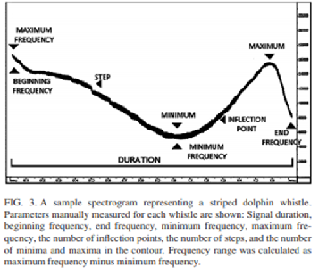

Sources:

1. J. N. Oswald, J. Barlow and T. F. Norris, Marine Mammal Science **19** (1), 20-37 (2003).